# PokemonGuide by **JUHYUNG**

variable ‘X’ is just numbering on the data. But R already shows the row number so we don’t need this variable.

In poke data, Type.2[38] is ‘273’. This is wrong data, since Type is consisted of ‘Fire’, ‘Water’ and so on, ‘273’(poke$Type.2[38]) is not a type.

# About the data.

```
## 'data.frame':    1600 obs. of  12 variables:
##  $ Name      : Factor w/ 799 levels "Abomasnow","AbomasnowMega Abomasnow",..: 81 330 745 746 103 104 100 101 102 665 ...
##  $ Total     : int  318 405 525 625 309 405 534 634 634 314 ...
##  $ HP        : int  45 60 80 80 39 58 78 78 78 44 ...
##  $ Attack    : int  49 62 82 100 52 64 84 130 104 48 ...
##  $ Defense   : int  49 63 83 123 43 58 78 111 78 65 ...
##  $ Sp..Atk   : int  65 80 100 122 60 80 109 130 159 50 ...
##  $ Sp..Def   : int  65 80 100 120 50 65 85 85 115 64 ...
##  $ Speed     : int  45 60 80 80 65 80 100 100 100 43 ...
##  $ Generation: Factor w/ 6 levels "1","2","3","4",..: 1 1 1 1 1 1 1 1 1 1 ...
##  $ Legendary : logi  FALSE FALSE FALSE FALSE FALSE FALSE ...
##  $ Type      : Factor w/ 2 levels "Type.1","Type.2": 1 1 1 1 1 1 1 1 1 1 ...
##  $ Type_value: chr  "Grass" "Grass" "Grass" "Grass" ...
```

This is pokemon dataset. The pokemons from generation 1 to 6. It contains the pokemon’s score, legendary, type, generation. This data is interesting to me, because i was a pokemon trainer with ‘gameboy’ when i was a child. This makes me think back to my childhood.

# Univariate Plots Section

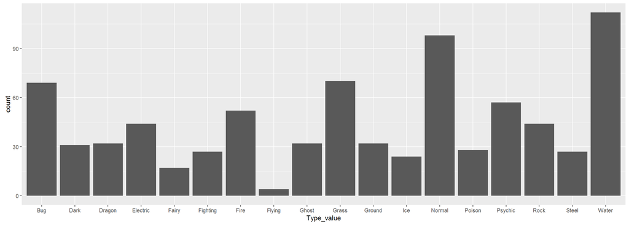

I need to count the number of pokemons in each Type. It’s not uniformly designed. The least is Flying type and the most is water type.

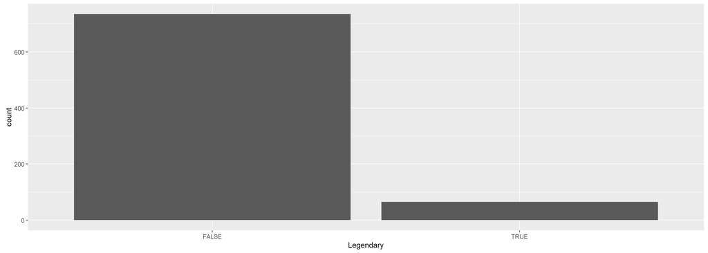

```
##    Mode   FALSE    TRUE    NA's
## logical     735      65       0
```

```
##    Mode   FALSE    TRUE    NA's
## logical    1470     130       0
```

I need to count how many legend pokemons are there. Naturally legend pokemon is much less than normal pokemon. There are about 10 times more normal pokemons than legend pokemon.

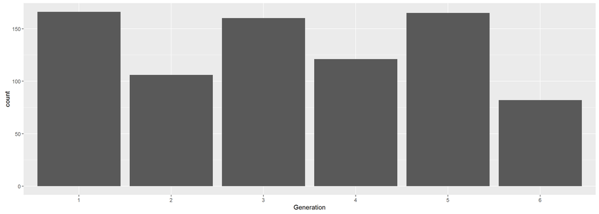

```
##   1   2   3   4   5   6
## 332 212 320 242 330 164
```

This plot shows how many pokemons are in each generations. Interestingly, in odds number of generation, about 50 pokemons were more made than even number of generation.

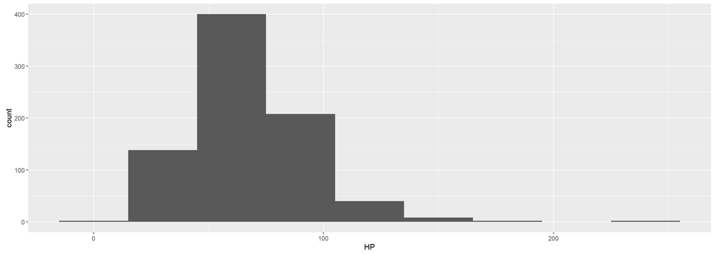

```
##    Min. 1st Qu.  Median    Mean 3rd Qu.    Max.
##    1.00   50.00   65.00   69.27   80.00  255.00
```

without outlier(HP=255). I observed it’s approximately normal.

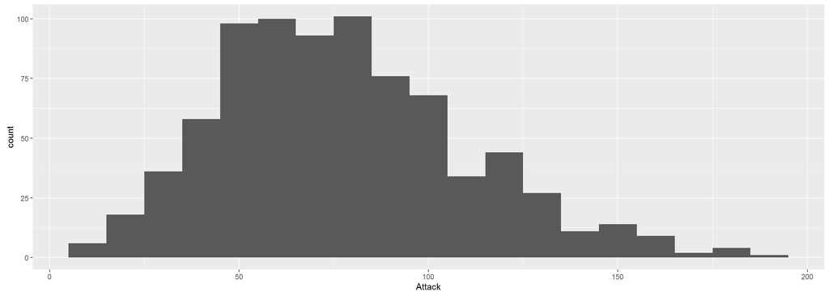

```
##    Min. 1st Qu.  Median    Mean 3rd Qu.    Max.
##    5.00   55.00   75.00   78.98  100.00  190.00
```

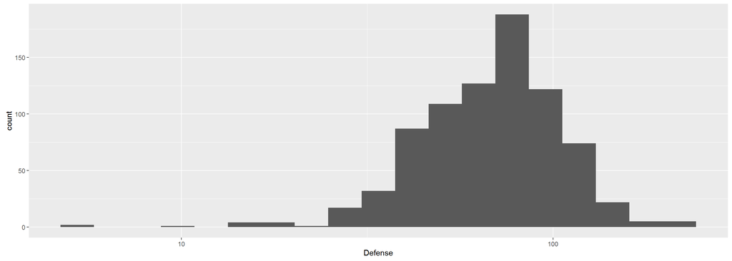

```
##    Min. 1st Qu.  Median    Mean 3rd Qu.    Max.
##    5.00   50.00   70.00   73.84   90.00  230.00
```

This plot is log-transformed and this is more close to normal. now it’s easier to work with.

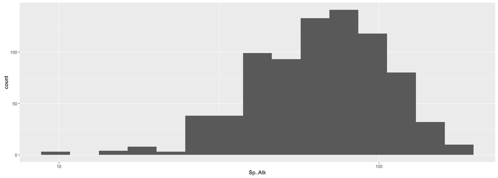

```
##    Min. 1st Qu.  Median    Mean 3rd Qu.    Max.
##   10.00   49.75   65.00   72.82   95.00  194.00
```

this was more skewed than Defense plot. and still skewed a little but much better.

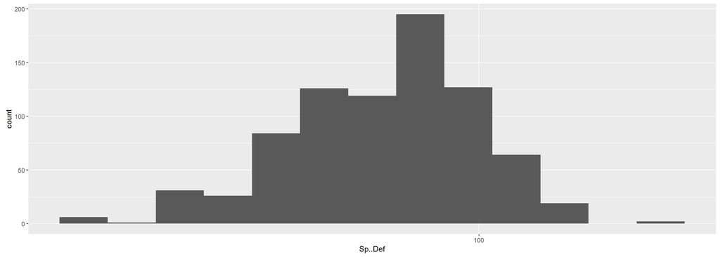

```
##    Min. 1st Qu.  Median    Mean 3rd Qu.    Max.
##   20.00   50.00   70.00   71.92   90.00  230.00
```

This is was a little ambiguous plot. After log-transformed it’s clear that it seems normal.

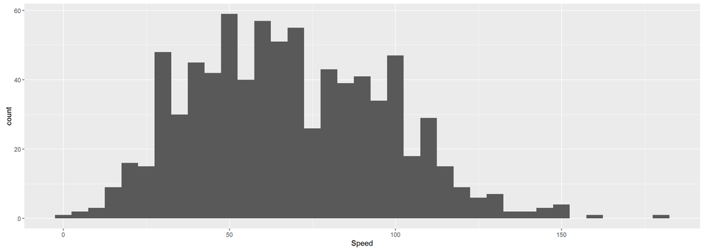

```
##    Min. 1st Qu.  Median    Mean 3rd Qu.    Max.
##    1.00   45.00   65.00   68.22   90.00  180.00
```

This is pretty normal.

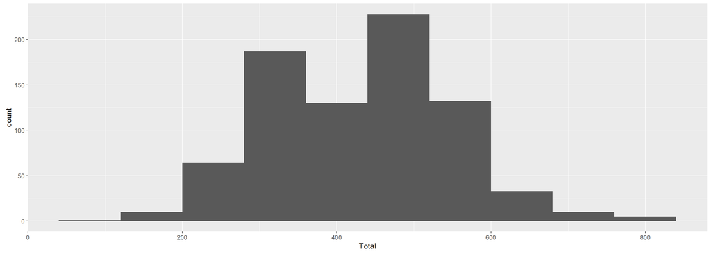

```
##    Min. 1st Qu.  Median    Mean 3rd Qu.    Max.
##    46.0   330.0   450.0   434.8   515.0   780.0
```

It seems histogram of some variables look normal and others look normal if log-transformed.

# Univariate Analysis

### What is the structure of your dataset?

pokemon dataset has 800 objects with 12 variables. Type.1 and Type.2 are features of that pokemon. it can be pokemon’s biological feature such as Bug, Dragon and also nature of it`s power such as Posion, Fighting. Numeric values Total~Speed is each pokemon’s score. Generation is when the pokemon made, there were pokemon animation season 1 to season 6. Legendary show whether the pokemon is lengend pokemon or not.

- Most of pokemons have 1 type.
- There are few of legendary pokemon.
- In odd number of generation, 1, 3, 5, there were more pokemons than even number of generation.

### What is/are the main feature(s) of interest in your dataset?

The main feature of this dataset is Total.Total is sum of HP, Attack, Defense, Sp..Atk, Sp..Def, Speed. Total decide how powerful the pokemon is.

### What other features in the dataset do you think will help support your investigation into your feature(s) of interest?

Legendary and type. Usually legend pokemons are powerful. and specific type of pokemon also powerful.

### Did you create any new variables from existing variables in the dataset?

No I just melt the data.

### Of the features you investigated, were there any unusual distributions? Did you perform any operations on the data to tidy, adjust, or change the form of the data? If so, why did you do this?

there was no unusual distribution. I made dataset poke2 that combine type.1 and type.2. Because Type.1 and Type.2 is same value but is seperated. So i melt it to use both of them.

# Bivariate Plots Section

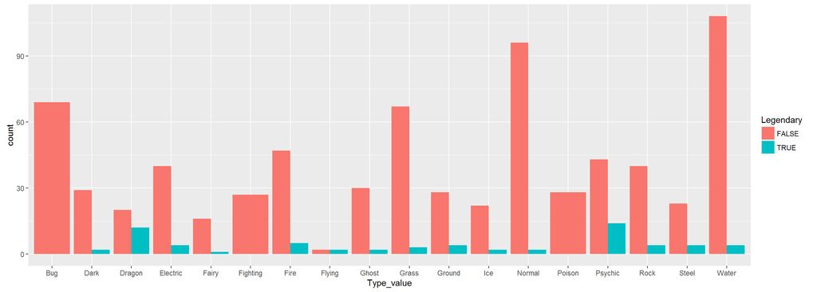

We saw the number of pokemons by legend and type above. But the one plot with these three is better. This shows there is no legend pokemon in bug, fighting and poison type and dragon, pshychic type has more legend pokemon than others

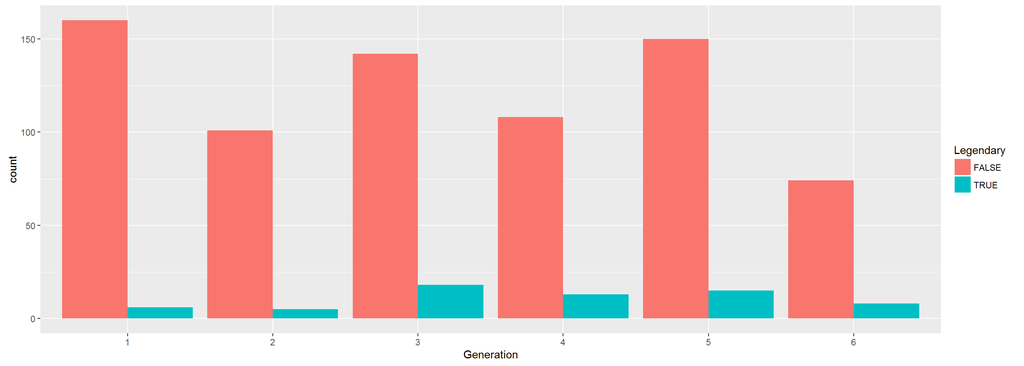

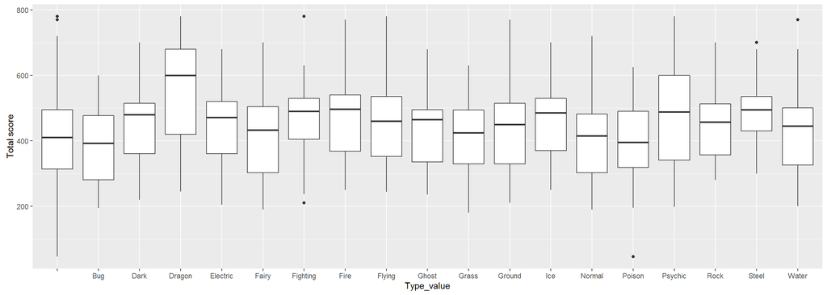

Now i’m wondering distribution of Total in each type. This helps to see which type of pokemon is strong. Dragon type is strongest, maybe because just they are dragon. Others show similar box plots.

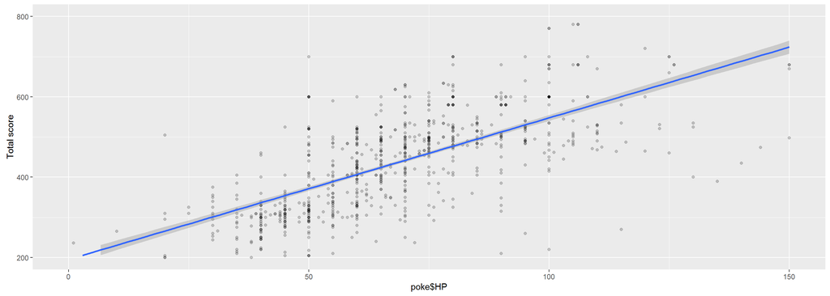

```
##
##  Pearson's product-moment correlation
##
## data:  poke$HP and poke$Total
## t = 31.264, df = 1598, p-value < 2.2e-16
## alternative hypothesis: true correlation is not equal to 0
## 95 percent confidence interval:
##  0.5846955 0.6455656
## sample estimates:
##       cor
## 0.6160494
```

I guess the pokemon with high HP normally has high Total. let’s check it. I can see my guess is pretty good in this plot. I can check it with linear method line.

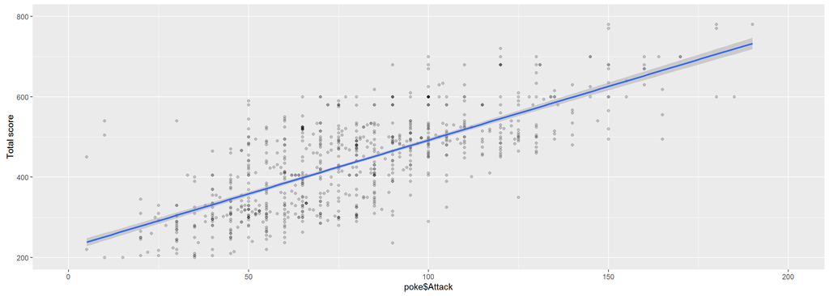

```
##
##  Pearson's product-moment correlation
##
## data:  poke$Attack and poke$Total
## t = 43.395, df = 1598, p-value < 2.2e-16
## alternative hypothesis: true correlation is not equal to 0
## 95 percent confidence interval:
##  0.7121595 0.7572098
## sample estimates:
##       cor
## 0.7354966
```

Also other variables may have linearity with Total. Attack shows good slope with Total.

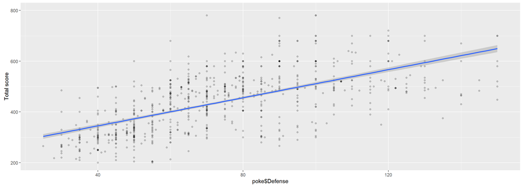

```
##
##  Pearson's product-moment correlation
##
## data:  poke$Defense and poke$Total
## t = 30.937, df = 1598, p-value < 2.2e-16
## alternative hypothesis: true correlation is not equal to 0
## 95 percent confidence interval:
##  0.5804420 0.6417945
## sample estimates:
##       cor
## 0.6120383
```

I can check correlation is 0.61, also plot looks it has linaer regression.

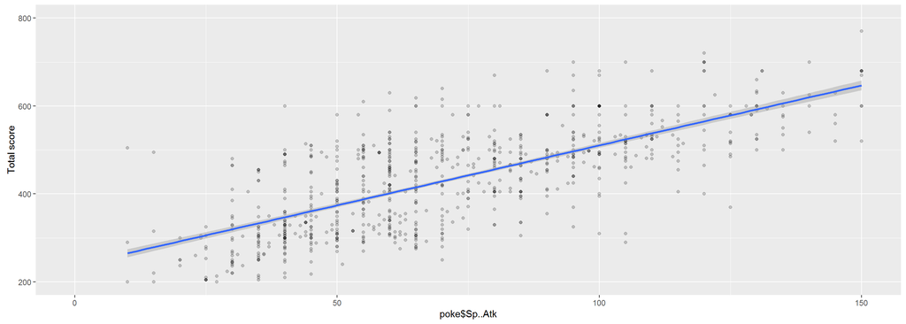

```
##
##  Pearson's product-moment correlation
##
## data:  poke$Sp..Atk and poke$Total
## t = 44.724, df = 1598, p-value < 2.2e-16
## alternative hypothesis: true correlation is not equal to 0
## 95 percent confidence interval:
##  0.7229924 0.7665784
## sample estimates:
##       cor
## 0.7455817
```

With correlation 0.74. It’s more linear than Defense. This means Sp..Atk is more important to guess pokemon’s Total.

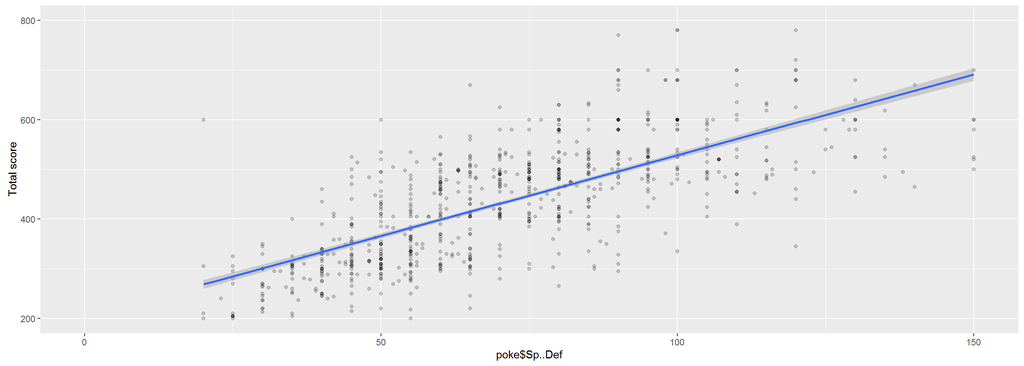

```
##
##  Pearson's product-moment correlation
##
## data:  poke$Sp..Def and poke$Total
## t = 40.918, df = 1598, p-value < 2.2e-16
## alternative hypothesis: true correlation is not equal to 0
## 95 percent confidence interval:
##  0.6904991 0.7384215
## sample estimates:
##       cor
## 0.7153002
```

With correlation 0.71. pretty high correlation. Sp..Atk, Sp..Def is important variable to pokemon.

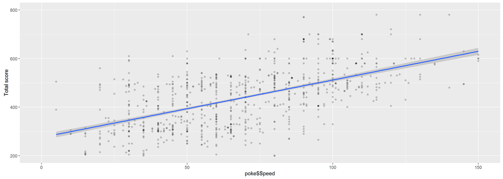

```
##
##  Pearson's product-moment correlation
##
## data:  poke$Speed and poke$Total
## t = 28.412, df = 1598, p-value < 2.2e-16
## alternative hypothesis: true correlation is not equal to 0
## 95 percent confidence interval:
##  0.5458149 0.6109846
## sample estimates:
##       cor
## 0.5793248
```

In this plot. The slope of the line is smaller than others, which means less correlation. And I can check it by cor.test, correlation = 0.5793

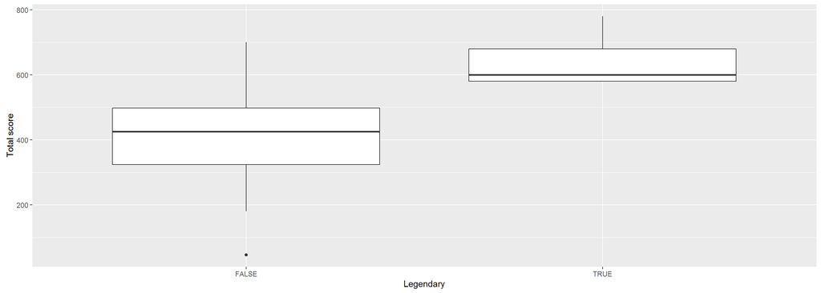

How legend pokemon stonger than others? this boxplot show legends are absolutely stronger than normal. But some normal pokemons are strong as legends.

# Bivariate Analysis

### Talk about some of the relationships you observed in this part of the investigation. How did the feature(s) of interest vary with other features in the dataset?

First There are much more none type of pokemons than other types, but each type of pokemons have similar range of Total except Dragon, they are powerful.

Second, The compositions of Total has linear regression with Total.

### What was the strongest relationship you found?

It is obvious that Lgendary pokemons have high Total score.

# Multivariate Plots Section

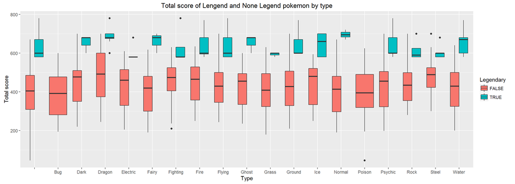

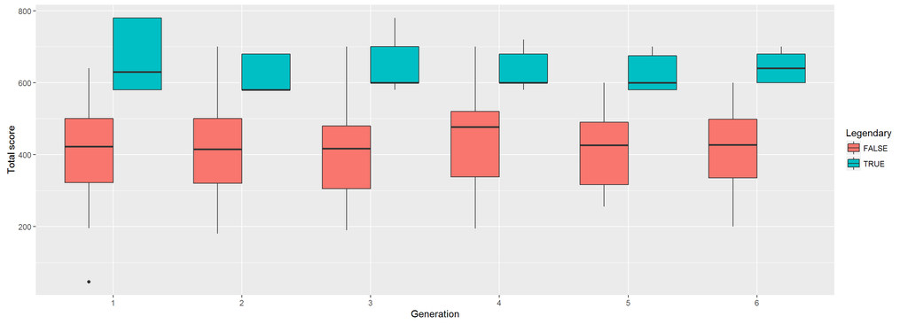

```
##       Name Total HP Attack Defense Sp..Atk Sp..Def Speed Generation
## 38 Nidoran    46 57     40      40      40      50     1          1
##    Legendary   Type Type_value
## 38     FALSE Type.1     Poison
```

it’s Nidoran. Don’t choose it when you play pokemon game.

```
##
## Call:
## lm(formula = Total ~ HP + Attack + Defense + Sp..Atk + Sp..Def +
##     Speed + Generation + Legendary + Type_value, data = poke)
##
## Residuals:
##      Min       1Q   Median       3Q      Max
## -179.108   -0.335    0.155    0.654    4.388
##
## Coefficients:
##                     Estimate Std. Error t value Pr(>|t|)
## (Intercept)        -3.043830   0.808259  -3.766 0.000172 ***
## HP                  0.999029   0.007665 130.330  < 2e-16 ***
## Attack              0.999108   0.006978 143.186  < 2e-16 ***
## Defense             1.009201   0.007224 139.697  < 2e-16 ***
## Sp..Atk             0.999884   0.006995 142.952  < 2e-16 ***
## Sp..Def             0.997113   0.008165 122.123  < 2e-16 ***
## Speed               1.023289   0.007042 145.304  < 2e-16 ***
## Generation2         1.132461   0.580810   1.950 0.051378 .
## Generation3         1.048837   0.518657   2.022 0.043323 *
## Generation4         0.982939   0.555906   1.768 0.077226 .
## Generation5         1.058959   0.514804   2.057 0.039850 *
## Generation6         0.993427   0.636409   1.561 0.118728
## LegendaryTRUE      -0.826051   0.697253  -1.185 0.236307
## Type_valueBug       0.416031   0.832808   0.500 0.617461
## Type_valueDark      0.008900   0.971640   0.009 0.992693
## Type_valueDragon    0.084971   0.991020   0.086 0.931683
## Type_valueElectric  0.070563   0.982682   0.072 0.942765
## Type_valueFairy     0.615021   1.088916   0.565 0.572290
## Type_valueFighting  0.164136   0.961664   0.171 0.864498
## Type_valueFire      0.290901   0.880004   0.331 0.741015
## Type_valueFlying    0.069268   0.730395   0.095 0.924457
## Type_valueGhost     0.353710   1.020496   0.347 0.728933
## Type_valueGrass     0.452790   0.741263   0.611 0.541397
## Type_valueGround    0.441268   0.869089   0.508 0.611710
## Type_valueIce       0.357223   1.097913   0.325 0.744948
## Type_valueNormal    0.358710   0.729002   0.492 0.622748
## Type_valuePoison   -2.088840   0.892882  -2.339 0.019438 *
## Type_valuePsychic   0.292290   0.773615   0.378 0.705613
## Type_valueRock      0.461869   0.943504   0.490 0.624539
## Type_valueSteel     0.122499   1.022573   0.120 0.904661
## Type_valueWater     0.466844   0.664343   0.703 0.482338
## ---
## Signif. codes:  0 '***' 0.001 '**' 0.01 '*' 0.05 '.' 0.1 ' ' 1
##
## Residual standard error: 6.427 on 1569 degrees of freedom
## Multiple R-squared:  0.9972, Adjusted R-squared:  0.9972
## F-statistic: 1.871e+04 on 30 and 1569 DF,  p-value: < 2.2e-16
```

from the regression model, i got R-squared: 0.99, which means 99% of Total is due to those variables. it’s pretty high R-squared because i put all variables. But it doesnt mean it always imply causation. Also HP~Speed has low Std.Error and P-value less than 0.001 which means good to estimate Total. P-value of Generation 3 and 5 is less than 0.05, so it`s a little bit help to estimate Total with esimated coefficient bigger than 0, Total with generation 3, 5 may be higher. P-value of Posion type is less than 0.05 and it’s Estimated coefficient is less than 0 that mean Posion type may have less Total.

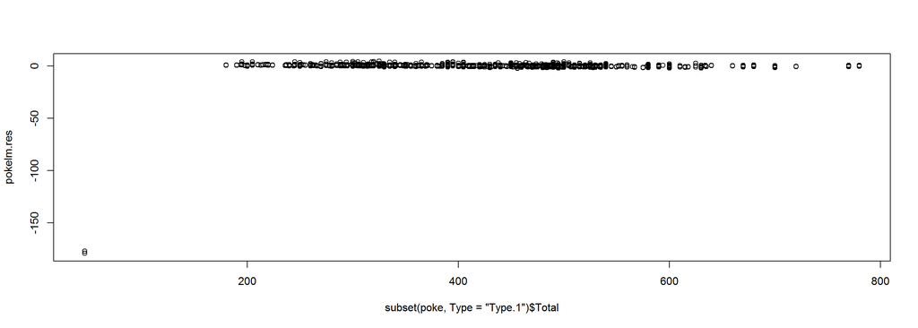

This is residual plot of regression. I observed the residual is almost 0 except 2 outliers. It’s pretty good plot excepting those 2 outliers. And I know those 2 outliers is Nidorans.

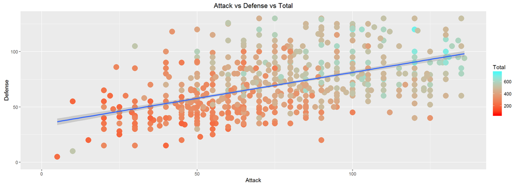

I’m wondering that the pokemon with high attack and defense may have high total too. This plot shows that by color and smooth linear method line.

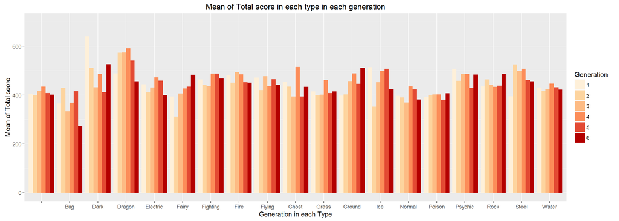

To help understanding I add one more plot.

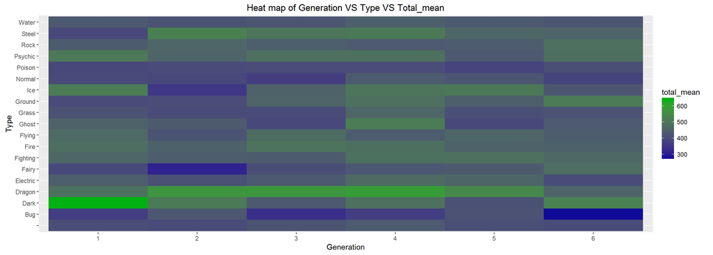

# Multivariate Analysis

### Talk about some of the relationships you observed in this part of the investigation. Were there features that strengthened each other in terms of looking at your feature(s) of interest?

As we observed in the bivariate plot, dragon is strongest type in pokemon. The upper quantile of non-legendary dragon type pokemon Total score is around the lower quantile of legendary other-type pokemon Total score. But in legendary pokemon, normal type legendary pokemon has highest score except outliers.

### Were there any interesting or surprising interactions between features?

It’s somewhat obvious that pokemons with high Attack, Defense score has high Total score.

### OPTIONAL: Did you create any models with your dataset? Discuss the strengths and limitations of your model.

I made linear regression model. From the model i observed that HP ~ Speed has P-value lower than 0.001 so it`s important factor.

Also Generation 3, Generation 5, Posion type has P-value lower than 0.05.

But Poison type has minus t-value.

So i reccomend to choose pokemon with generation 3 or 5 and avoid Poison type pokemon. if you want to be a pokemon trainer.

# Final Plots and Summary

### Plot One

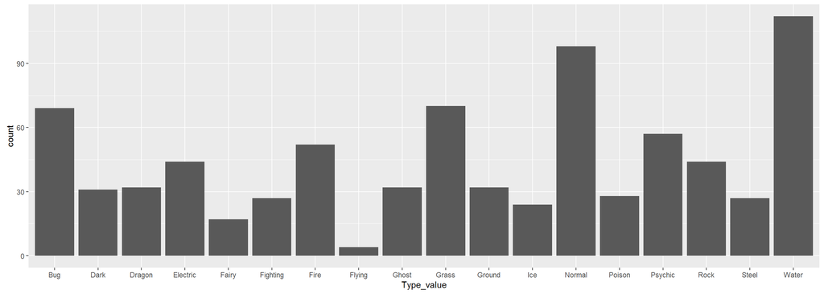

### Description One

I choose this plot in unvariate plot. Because, To start Pokemon, choosing type is important. It decide the direction of pokemon trainer. So getting information about types of pokemon is essential. Some types are strong and some are weak. But trainer should think about the relation between types. From this plot some types are common like water, normal, grass, and others like flying, fairy are rare. From information like this, trainer should decide which type he will collect next.

### Plot Two

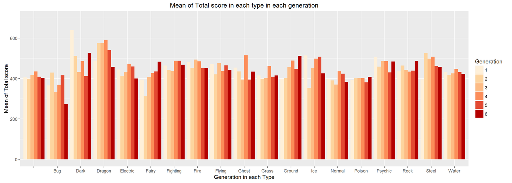

### Plot Three

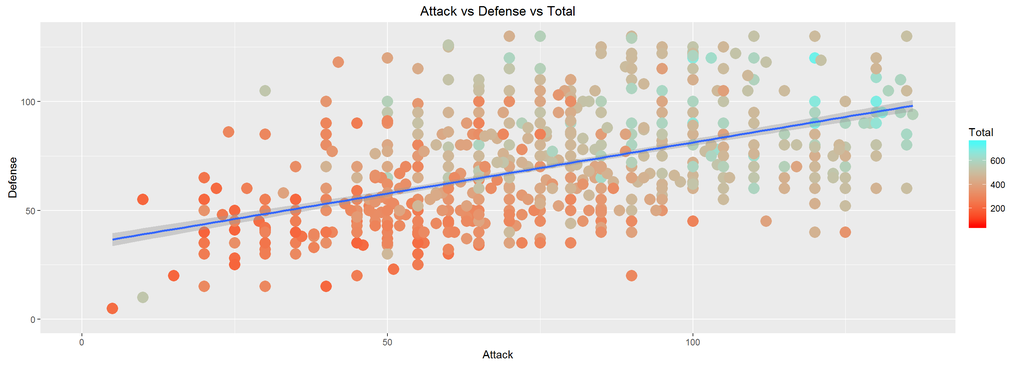

### Description Three

the tratiners may be suspicious that how Attack and Defense is related on Total score. To them, I recommend to check this. The plot shows left-down side points are dark and right-up side points are brighter. so I can say high attack, defense pokemons has high total.

# Reflection

With this project I experienced how important to collect data in tidy set. If just one data is wrong, it doesn’t work at all. I agree with ‘Data Science is 80% of data wrangling and 20% of research’. During the research I’ve wanted to use linear regression. As I have a little knowledge about linear regression, I applied it simply.

Future Work There will be pokemon generation 7 or new generation I guess, with this analysis trainer can research about new pokemons like guessing the total with new pokemon data that it gets.